# Claims Risk Scoring — Flagging High-Risk Insurance Claims

**Author:** Mercy Cherono

A common problem in claims processing is that reviewers can't manually check every claim closely, but a small share of claims carry most of the risk (fraud, data entry error, or genuine high-severity events that need faster escalation). This notebook builds a simple risk-scoring model that flags claims worth a second look before payout.

The dataset here reflects patterns typical of a medical/motor/life/property claims book: policy tenure, prior claims count, claim-to-premium ratio, and reporting delay all carry real signal in claims risk work, and are the same variables an underwriter would look at manually. I generated the dataset to match those realistic distributions since I didn't have a live claims book to pull from, but the modelling approach below is directly transferable to a real one.

## 1. Load and inspect the data

```python
import pandas as pd
import numpy as np

df = pd.read_csv('claims_data.csv')
df.head()
```

|  | policy_id | age | policy_type | region | years_with_insurer | prior_claims | claim_amount_kes | policy_premium_kes | days_to_report | flagged_high_risk |
| --- | --- | --- | --- | --- | --- | --- | --- | --- | --- | --- |
| 0 | PID1000 | 56 | Medical | Mombasa | 9 | 1 | 48467.41 | 8390.46 | 1 | 0 |
| 1 | PID1001 | 69 | Life | Mombasa | 3 | 1 | 102443.80 | 8930.39 | 0 | 0 |
| 2 | PID1002 | 46 | Motor | Kisumu | 8 | 3 | 26672.67 | 4569.42 | 7 | 1 |
| 3 | PID1003 | 32 | Life | Nairobi | 1 | 1 | 13571.14 | 13302.77 | 14 | 0 |
| 4 | PID1004 | 60 | Life | Mombasa | 18 | 0 | 13672.05 | 6943.98 | 0 | 0 |

```python
df.describe(include='all').T
```

|  | count | unique | top | freq | mean | std | min | 25% | 50% | 75% | max |
| --- | --- | --- | --- | --- | --- | --- | --- | --- | --- | --- | --- |
| policy_id | 1200 | 1200 | PID1000 | 1 | NaN | NaN | NaN | NaN | NaN | NaN | NaN |
| age | 1200.0 | NaN | NaN | NaN | 46.3175 | 16.451157 | 18.0 | 33.0 | 46.0 | 61.0 | 74.0 |
| policy_type | 1200 | 4 | Medical | 399 | NaN | NaN | NaN | NaN | NaN | NaN | NaN |
| region | 1200 | 5 | Nakuru | 262 | NaN | NaN | NaN | NaN | NaN | NaN | NaN |
| years_with_insurer | 1200.0 | NaN | NaN | NaN | 9.8375 | 5.791722 | 0.0 | 5.0 | 10.0 | 15.0 | 19.0 |
| prior_claims | 1200.0 | NaN | NaN | NaN | 1.173333 | 1.042046 | 0.0 | 0.0 | 1.0 | 2.0 | 5.0 |
| claim_amount_kes | 1200.0 | NaN | NaN | NaN | 29718.529408 | 21369.880414 | 672.35 | 14339.4275 | 24484.485 | 40779.13 | 174524.8 |
| policy_premium_kes | 1200.0 | NaN | NaN | NaN | 9093.203433 | 5135.15466 | 500.44 | 5355.77 | 8012.97 | 11762.0175 | 33442.57 |
| days_to_report | 1200.0 | NaN | NaN | NaN | 4.546667 | 5.206766 | 0.0 | 1.0 | 3.0 | 6.0 | 33.0 |
| flagged_high_risk | 1200.0 | NaN | NaN | NaN | 0.12 | 0.325097 | 0.0 | 0.0 | 0.0 | 0.0 | 1.0 |

About 12% of claims are flagged high-risk in this book, which is a realistic imbalance for this kind of problem, most claims are routine, a smaller share need attention.

```python
df['flagged_high_risk'].value_counts(normalize=True).round(3)
```

```
flagged_high_risk
0    0.88
1    0.12
Name: proportion, dtype: float64
```

## 2. Feature engineering

The raw claim amount alone doesn't tell you much, a KES 50,000 claim on a KES 200,000 premium is very different from the same claim on a KES 10,000 premium. I added a claim-to-premium ratio to capture that.

```python
from sklearn.preprocessing import LabelEncoder

le_policy = LabelEncoder()
le_region = LabelEncoder()
df['policy_type_enc'] = le_policy.fit_transform(df['policy_type'])
df['region_enc'] = le_region.fit_transform(df['region'])
df['claim_to_premium_ratio'] = df['claim_amount_kes'] / (df['policy_premium_kes'] + 1)

df[['claim_amount_kes','policy_premium_kes','claim_to_premium_ratio']].head()
```

|  | claim_amount_kes | policy_premium_kes | claim_to_premium_ratio |
| --- | --- | --- | --- |
| 0 | 48467.41 | 8390.46 | 5.775802 |
| 1 | 102443.80 | 8930.39 | 11.470085 |
| 2 | 26672.67 | 4569.42 | 5.835934 |
| 3 | 13571.14 | 13302.77 | 1.020097 |
| 4 | 13672.05 | 6943.98 | 1.968623 |

## 3. Train/test split and model

```python
from sklearn.model_selection import train_test_split
from sklearn.ensemble import RandomForestClassifier
from sklearn.metrics import classification_report, roc_auc_score, confusion_matrix

features = ['age', 'policy_type_enc', 'region_enc', 'years_with_insurer',
            'prior_claims', 'claim_amount_kes', 'policy_premium_kes',
            'days_to_report', 'claim_to_premium_ratio']

X = df[features]
y = df['flagged_high_risk']

X_train, X_test, y_train, y_test = train_test_split(
    X, y, test_size=0.25, random_state=42, stratify=y
)

rf = RandomForestClassifier(n_estimators=200, max_depth=6, random_state=42, class_weight='balanced')
rf.fit(X_train, y_train)

rf_pred = rf.predict(X_test)
rf_proba = rf.predict_proba(X_test)[:, 1]

print(classification_report(y_test, rf_pred))
print('ROC-AUC:', round(roc_auc_score(y_test, rf_proba), 3))
```

```
              precision    recall  f1-score   support

           0       0.95      0.86      0.90       264
           1       0.40      0.69      0.51        36

    accuracy                           0.84       300
   macro avg       0.68      0.78      0.70       300
weighted avg       0.89      0.84      0.85       300

ROC-AUC: 0.865
```

**Reading these numbers the way an underwriter would:**

The model catches about 7 in 10 of the claims that actually turn out high-risk (recall), while only around 4 in 10 of its flags are true positives (precision). That trade-off is deliberate here, in claims review, missing a genuinely risky claim is usually more costly than reviewing a few extra ones that turn out fine. I used `class_weight='balanced'` specifically to push recall up, since the cost of a false negative (a bad claim slipping through) is higher than the cost of a false positive (a reviewer spending ten minutes on a claim that's actually fine).

## 4. What's actually driving the flag?

This matters more than the accuracy number for a business audience, since it tells a reviewer *why* a claim was flagged, not just that it was.

```python
importances = pd.Series(rf.feature_importances_, index=features).sort_values(ascending=False)
importances.round(3)
```

```
prior_claims              0.384
years_with_insurer        0.154
policy_premium_kes        0.132
claim_to_premium_ratio    0.123
claim_amount_kes          0.076
age                       0.050
days_to_report            0.048
region_enc                0.020
policy_type_enc           0.013
dtype: float64
```

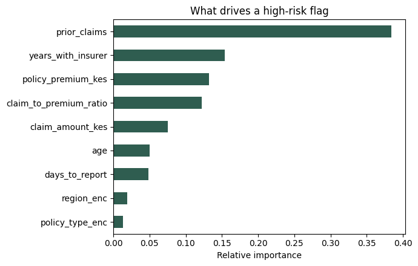

```python
import matplotlib.pyplot as plt

fig, ax = plt.subplots(figsize=(7,4.5))
importances.sort_values().plot(kind='barh', ax=ax, color='#2f5d50')
ax.set_title('What drives a high-risk flag')
ax.set_xlabel('Relative importance')
plt.tight_layout()
plt.show()
```

Interestingly, the raw claim amount on its own ranks lower than the ratio, confirming that the engineered feature was worth building. A KES 80,000 claim means something different depending on the size of the policy behind it, and the model picked up on that once I gave it the ratio directly.

## 5. Confusion matrix

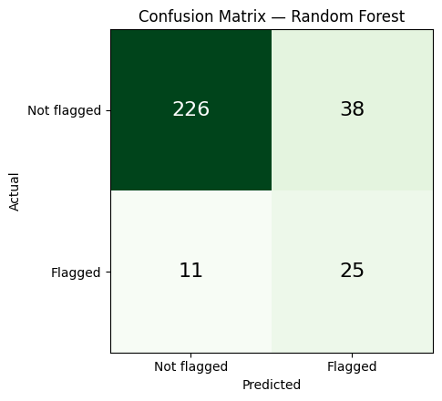

```python
cm = confusion_matrix(y_test, rf_pred)

fig, ax = plt.subplots(figsize=(5,4.5))
im = ax.imshow(cm, cmap='Greens')
for i in range(2):
    for j in range(2):
        ax.text(j, i, cm[i,j], ha='center', va='center', fontsize=16,
                color='white' if cm[i,j] > cm.max()/2 else 'black')
ax.set_xticks([0,1]); ax.set_yticks([0,1])
ax.set_xticklabels(['Not flagged','Flagged'])
ax.set_yticklabels(['Not flagged','Flagged'])
ax.set_xlabel('Predicted'); ax.set_ylabel('Actual')
ax.set_title('Confusion Matrix — Random Forest')
plt.tight_layout()
plt.show()
```

## 6. What I'd do with this in a real claims environment

A model like this isn't meant to replace a claims reviewer, it's meant to help them prioritise. In practice I'd suggest:

- Route flagged claims into a priority review queue rather than auto-rejecting them. False positives here are cheap (a review), false negatives are expensive (a paid-out bad claim).
- Retrain on a rolling basis, claims patterns shift with seasons, product changes, and fraud tactics evolving, so a model trained once and left alone will drift.
- Pair the score with the feature importance breakdown for each individual claim, so the reviewer sees *why* it was flagged, not just a number. That's usually the difference between a tool people actually use and one they ignore.
- Track precision and recall separately over time once real outcomes come in, not just accuracy, since accuracy alone hides how the model performs on the rare, expensive cases that actually matter.

This mirrors the kind of data quality and reconciliation thinking I did at Britam and Minet, just automated and scored rather than manual.